# Gas Production Forecast

Siva Bulusu

13/12/2019

Import required libraries

```r
library(forecast)
library(xts)
library(ggfortify)
library(tseries)
```

Read gas dataset.

```r
data("gas")
gas.ts <- gas
View(gas.ts)
```

Check the dataset is time series.

```r
class(gas.ts)
```

```
## [1] "ts"
```

```r
str(gas.ts)
```

```
##  Time-Series [1:476] from 1956 to 1996: 1709 1646 1794 1878 2173 ...
```

The input dataset “gas” is in time series format. There are 476 observations from 1956 to 1996.

Check the start, end and frequency of data and periodicity of dataset.

```r
start(gas.ts)
```

```
## [1] 1956    1
```

```r
end(gas.ts)
```

```
## [1] 1995    8
```

```r
frequency(gas.ts)
```

```
## [1] 12
```

```r
#39 years 8 months ie. 468+8 =476 observations ,
#each observation is for month starting from jan 1956 till aug 1995
```

Check the periodicity of data.

```r
periodicity(gas.ts)
```

```
## Monthly periodicity from Jan 1956 to Aug 1995
```

The dataset has Monthly periodicity. It has 476 observations. Each observation is for month starting from Jan 1956 till Aug 1995(39 years 8 months i.e. 468+8 = 476 months)

Plot the dataset.

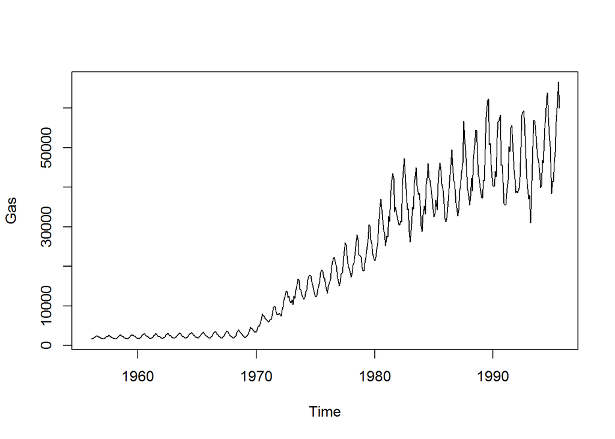

```r
plot(gas,ylab="Gas",pch=20)
```

Seasonality is observed throughout the period. From 1970 onwards there is an upward trend along with seasonality.

Draw trend line to see overall trend.

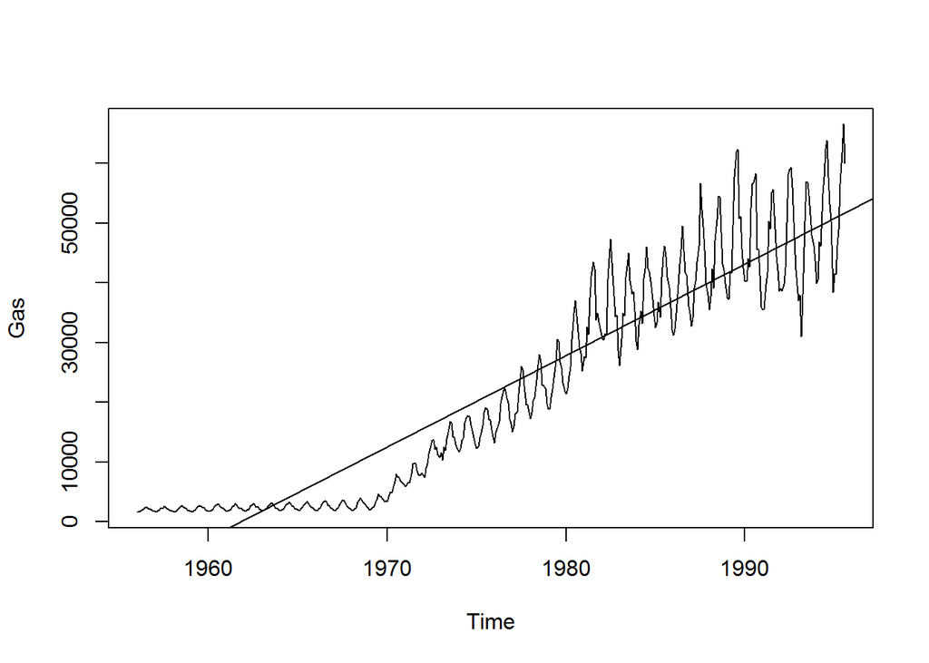

```r
plot(gas,ylab="Gas",pch=20)
abline(reg = lm(gas~time(gas.ts)))
```

Overall upward trend is observed.

Decompose the time series and plot the decomposed series. Plot the components as well.

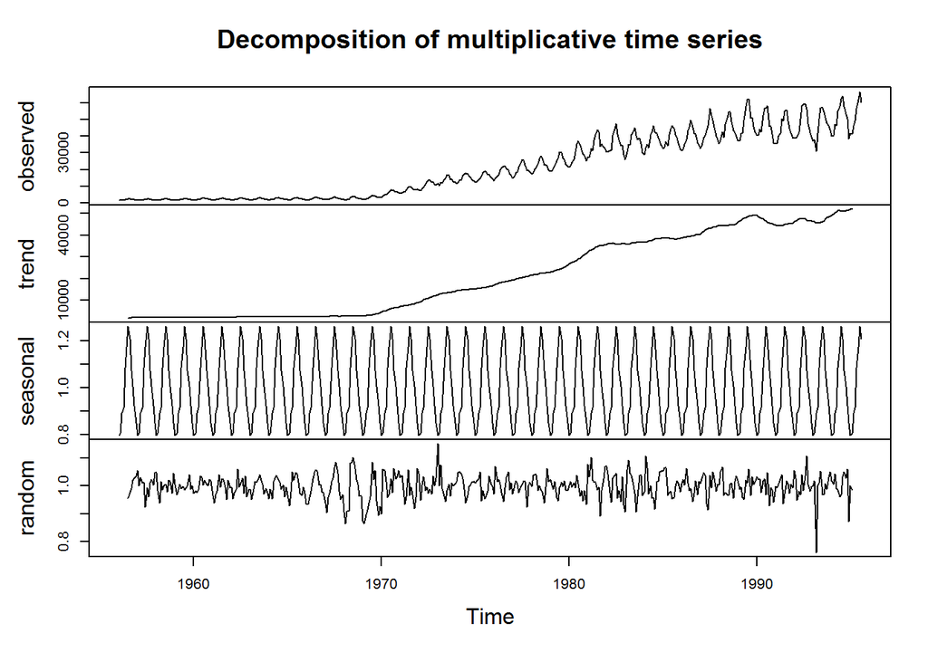

```r
gas.decompM <- decompose(gas.ts,type = "multiplicative")
plot(gas.decompM,ylab="Decomposed Time Series",pch=20)
```

Observed values have both trend and seasonality.

Check the seasonal component of decomposed time series and plot it.

```r
gas.decompM$seasonal
```

```
##            Jan       Feb       Mar       Apr       May       Jun       Jul
## 1956 0.7985855 0.8081005 0.8909405 0.9144269 1.0870273 1.1737483 1.2619705
## 1957 0.7985855 0.8081005 0.8909405 0.9144269 1.0870273 1.1737483 1.2619705
## 1958 0.7985855 0.8081005 0.8909405 0.9144269 1.0870273 1.1737483 1.2619705
## 1959 0.7985855 0.8081005 0.8909405 0.9144269 1.0870273 1.1737483 1.2619705
## 1960 0.7985855 0.8081005 0.8909405 0.9144269 1.0870273 1.1737483 1.2619705
## 1961 0.7985855 0.8081005 0.8909405 0.9144269 1.0870273 1.1737483 1.2619705
## 1962 0.7985855 0.8081005 0.8909405 0.9144269 1.0870273 1.1737483 1.2619705
## 1963 0.7985855 0.8081005 0.8909405 0.9144269 1.0870273 1.1737483 1.2619705
## 1964 0.7985855 0.8081005 0.8909405 0.9144269 1.0870273 1.1737483 1.2619705
## 1965 0.7985855 0.8081005 0.8909405 0.9144269 1.0870273 1.1737483 1.2619705
## 1966 0.7985855 0.8081005 0.8909405 0.9144269 1.0870273 1.1737483 1.2619705
## 1967 0.7985855 0.8081005 0.8909405 0.9144269 1.0870273 1.1737483 1.2619705
## 1968 0.7985855 0.8081005 0.8909405 0.9144269 1.0870273 1.1737483 1.2619705
## 1969 0.7985855 0.8081005 0.8909405 0.9144269 1.0870273 1.1737483 1.2619705
```

[output cut: 67 more lines]

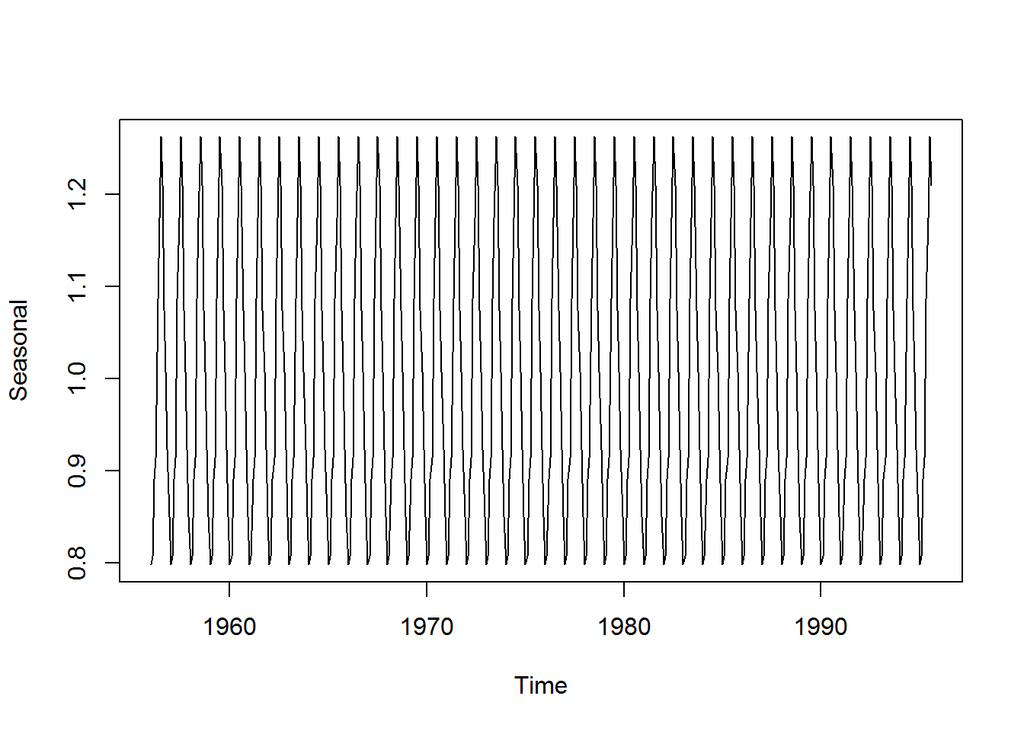

```r
plot(gas.decompM$seasonal,ylab="Seasonal",pch=20)
```

Seasonality is clearly visible in the gas time series from above plot.

Check box plot and season plot across months to get us a sense on seasonal effect.

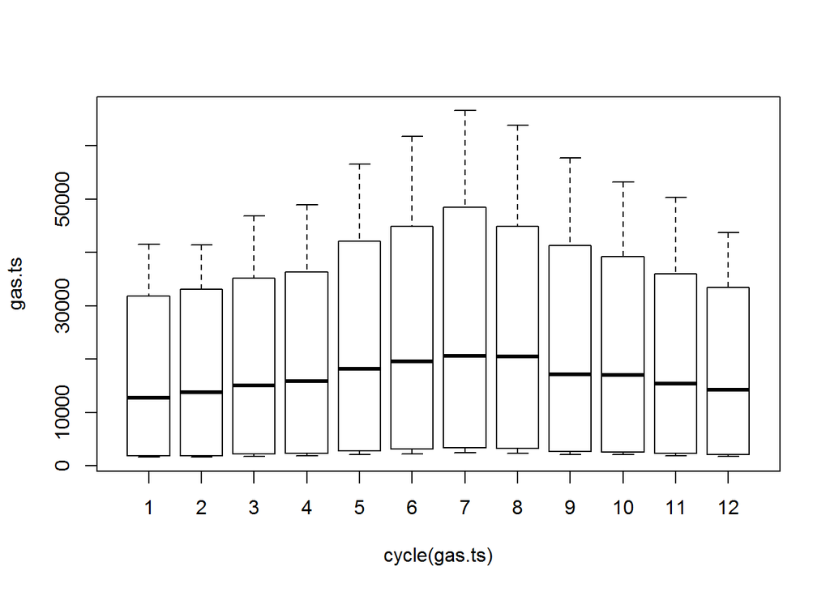

```r
boxplot(gas.ts~cycle(gas.ts))
```

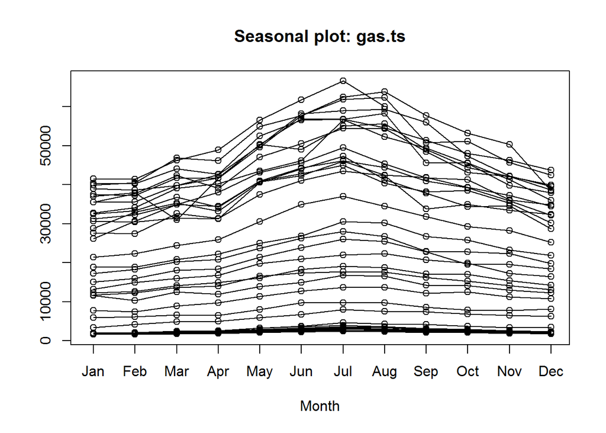

```r
seasonplot(gas.ts)
```

Check the trend component of decomposed time series and plot it.

```r
gas.decompM$trend
```

```
##            Jan       Feb       Mar       Apr       May       Jun       Jul
## 1956        NA        NA        NA        NA        NA        NA  2043.167
## 1957  2079.250  2087.667  2092.958  2098.667  2099.542  2100.875  2104.000
## 1958  2117.750  2123.917  2129.625  2133.583  2134.500  2135.417  2134.958
## 1959  2151.500  2155.875  2161.125  2166.833  2175.625  2179.583  2180.917
## 1960  2265.958  2287.500  2305.542  2314.750  2324.833  2337.583  2344.167
## 1961  2336.167  2337.458  2335.250  2328.250  2322.542  2320.333  2321.250
## 1962  2350.292  2354.708  2358.708  2370.167  2378.083  2376.292  2379.333
## 1963  2418.833  2429.375  2438.583  2441.208  2442.542  2449.583  2450.458
## 1964  2479.125  2481.333  2483.083  2488.792  2493.625  2496.292  2502.875
## 1965  2533.583  2540.167  2541.917  2538.833  2539.708  2542.333  2538.833
## 1966  2556.000  2573.125  2591.167  2607.875  2619.292  2625.875  2633.333
## 1967  2656.625  2667.625  2681.708  2687.417  2684.750  2685.167  2686.917
## 1968  2753.208  2773.917  2785.792  2803.375  2824.500  2839.458  2847.792
## 1969  2941.875  3000.292  3074.583  3153.708  3223.167  3303.208  3401.750
```

[output cut: 67 more lines]

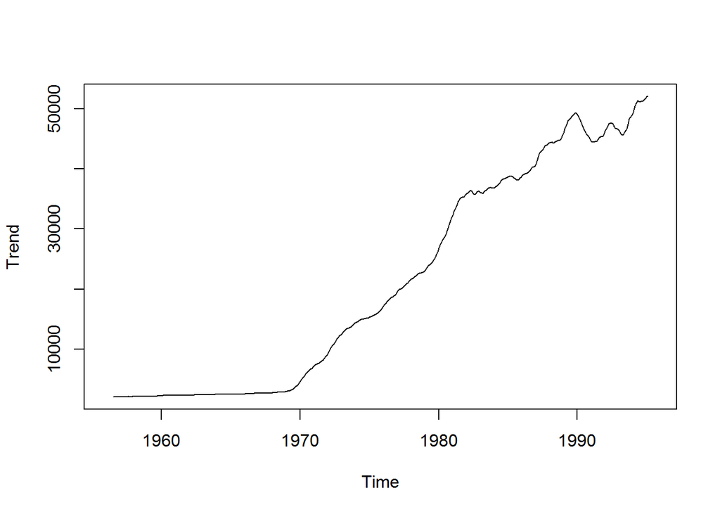

```r
plot(gas.decompM$trend,ylab="Trend",pch=20)
```

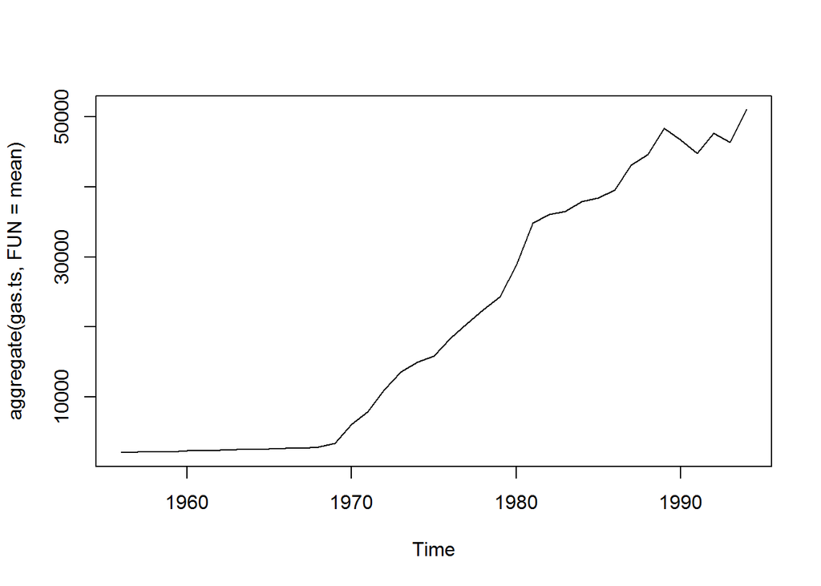

```r
#Aggregate the cycles and display a year on year trend
plot(aggregate(gas.ts,FUN=mean))
```

Till1970 no trend is observed. After 1970 we can see an upward trend in the time series.

Check the random component of decomposed time series and plot it.

```r
gas.decompM$random
```

```
##            Jan       Feb       Mar       Apr       May       Jun       Jul
## 1956        NA        NA        NA        NA        NA        NA 0.9571768
## 1957 1.0545277 1.0005663 1.0296555 1.0114236 1.0125932 0.9242067 0.9935274
## 1958 1.0483652 0.9834891 0.9397222 1.0169113 0.9869584 1.0018186 1.0065864
## 1959 1.0068930 0.9689101 0.9862712 1.0063537 0.9902900 0.9979352 0.9853747
## 1960 0.9737166 0.9818613 0.9760964 0.9869277 1.0355509 1.0307120 1.0022752
## 1961 0.9669662 0.9386409 0.9684851 0.9812052 1.0405336 0.9957821 1.0265079
## 1962 0.9952534 0.9538369 0.9740806 0.9883064 1.0611048 0.9949202 1.0084430
## 1963 0.9887944 0.9515178 0.9762350 1.0159895 1.0131409 1.0201050 1.0406136
## 1964 0.9541400 0.9894439 0.9537674 1.0154590 1.0274332 1.0371949 1.0223031
## 1965 0.9697111 0.9304772 0.9784975 1.0497173 1.0203814 1.0465609 1.0440294
## 1966 0.9357312 0.9334676 0.9598994 0.9820896 1.0266077 1.0476567 1.0571171
## 1967 0.9398823 0.9055025 0.9584627 0.9745890 1.0159688 1.0276961 1.0640527
## 1968 0.9069110 0.8658980 0.9097595 0.9097003 1.0823016 1.0825701 1.1010540
## 1969 0.8755655 0.8661446 0.8973191 0.9147539 0.9395861 0.9605030 1.0836477
```

[output cut: 67 more lines]

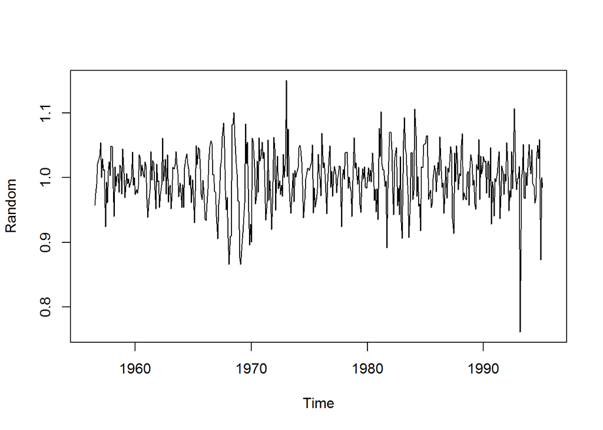

```r
plot(gas.decompM$random,ylab="Random",pch=20)
```

There is no upward or downward movements. It is moving similarly throughout the series.

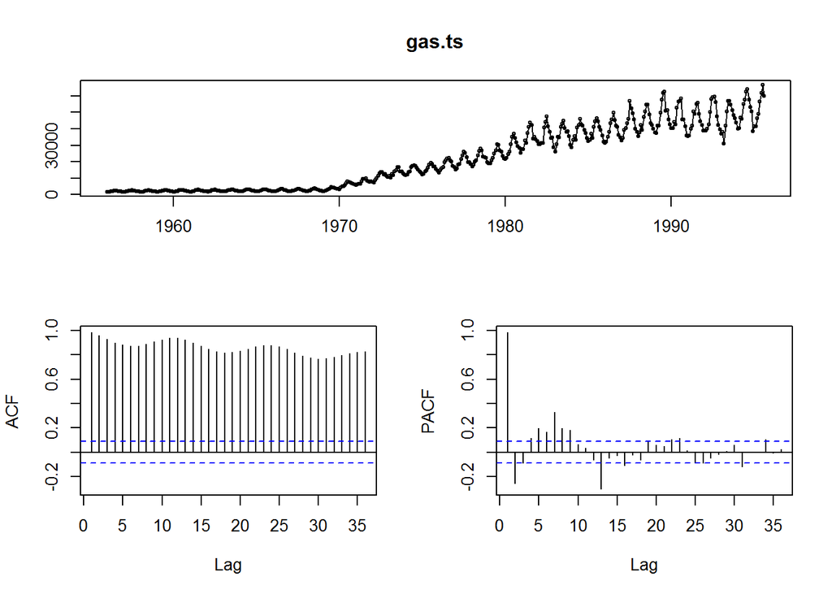

```r
tsdisplay(gas.ts)
```

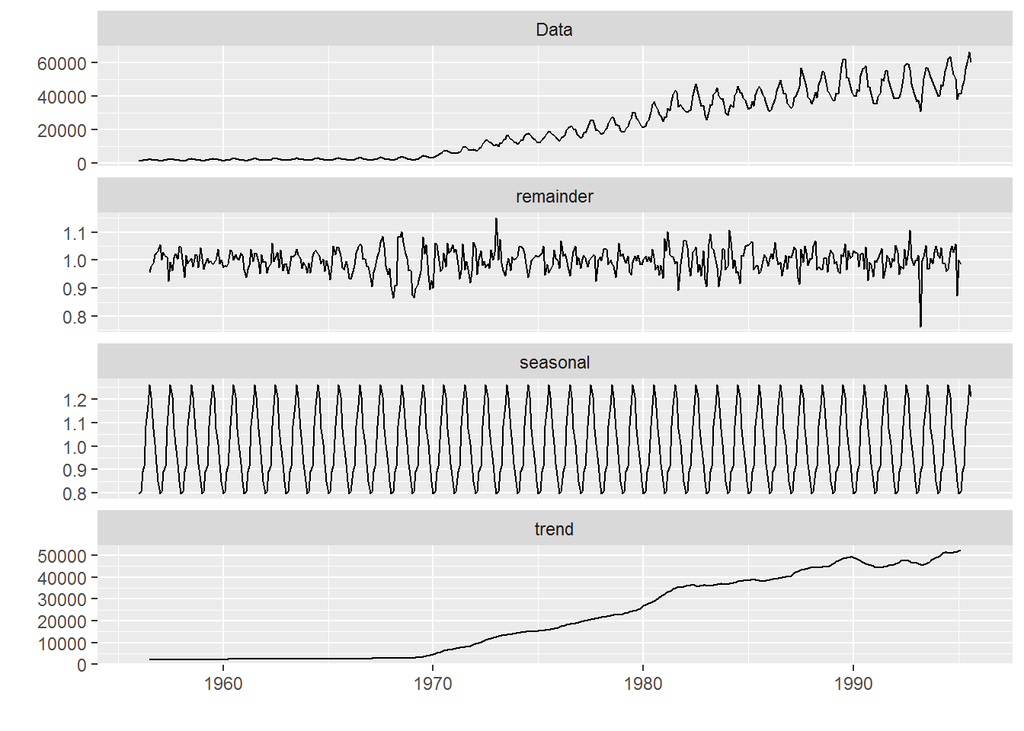

```r
autoplot(gas.decompM)
```

**Time series Stationarity**

Check the stationarity of time series using ADF test.

Null Hypothesis(H0): The series has a unit root. That means the time series is non-stationary. Alternate Hypothesis(H1): The series does not have a unit root. That means the time series is stationary.

```r
adf.test(gas.ts)
```

```
##
##  Augmented Dickey-Fuller Test
##
## data:  gas.ts
## Dickey-Fuller = -2.7131, Lag order = 7, p-value = 0.2764
## alternative hypothesis: stationary
```

p-value = 0.2764 > 0.05 hence we cannot reject the null hypothesis. So, as per Augmented Dickey-Fuller Test, the time series is non-stationary.

Check the stationarity of time series using KPSS test.

```r
kpss.test(gas.ts)
```

```
##
##  KPSS Test for Level Stationarity
##
## data:  gas.ts
## KPSS Level = 7.7018, Truncation lag parameter = 5, p-value = 0.01
```

p-value = 0.01 < 0.05 hence we can reject the null hypothesis. So, as per Kwiatkowski–Phillips–Schmidt–Shin Test, the time series is non-stationary.

Only stationary data can be used for ARIMA model. However, the data we have is non-stationary. So, let’s try to check the transformation and differencing techniques in order to make the data stationary.

A stationary time series is one whose statistical properties such as mean, variance, autocorrelation, etc. are all constant over time. Let us plot and see by applying the techniques to make the data stationary.

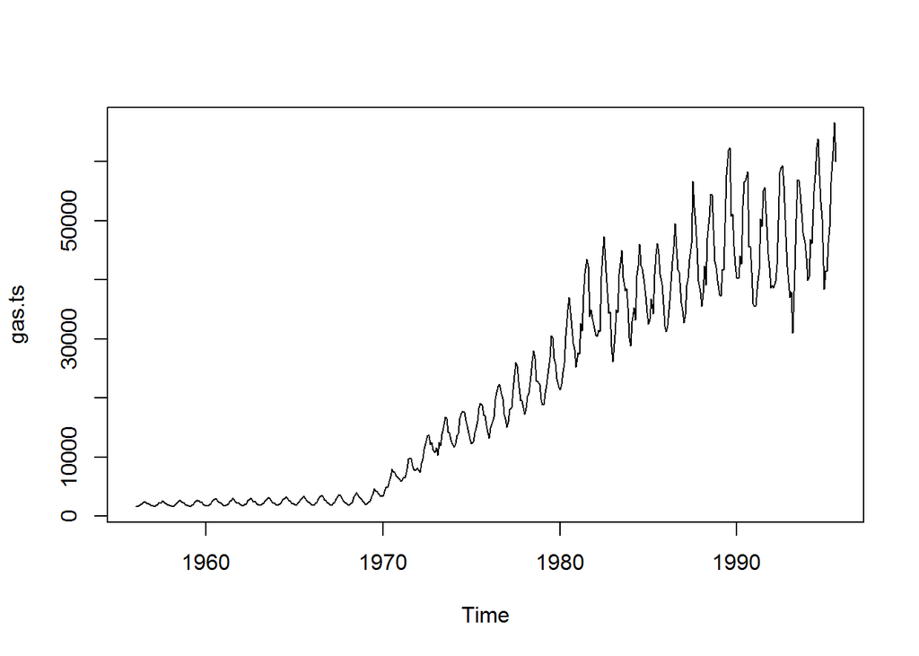

```r
#Plot the gas time series
plot(gas.ts)
```

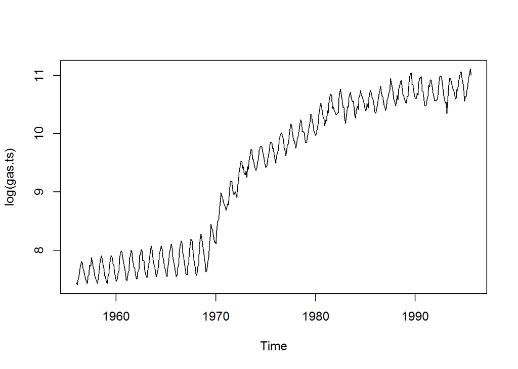

```r
#Plot log of gas time series
plot(log(gas.ts))
```

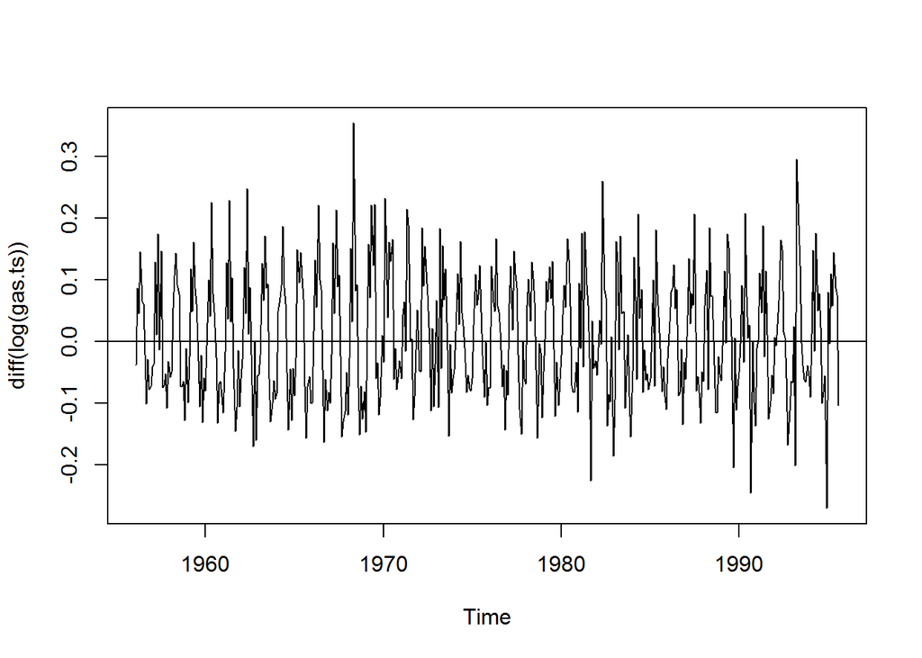

```r
#Plot diff log of gas time series
plot(diff(log(gas.ts)))
abline(h=0)
```

In the plot of gas time series, we can see that the mean not constant over period of time. It is moving upward. Log of the time series is also like the same. Difference of log time series is showing stationarity. In this plot we can see that the mean is the same over period of time. So, applying diff (log()) on the gas time series makes the data stationary. Let us check this with ADF and KPSS tests.

Check the stationarity for diff log of time series using ADF test.

Null Hypothesis(H0): The series has a unit root. That means the time series is non-stationary. Alternate Hypothesis(H1): The series does not have a unit root. That means the time series is stationary.

```r
adf.test(diff(log(gas.ts)))
```

```
##
##  Augmented Dickey-Fuller Test
##
## data:  diff(log(gas.ts))
## Dickey-Fuller = -17.55, Lag order = 7, p-value = 0.01
## alternative hypothesis: stationary
```

p-value = 0.01 < 0.05 hence we can reject the null hypothesis. So, as per Augmented Dickey-Fuller Test, the diff log of time series is stationary.

Check the stationarity for diff log of time series using KPSS test.

Null Hypothesis(H0): The data is stationary. Alternate Hypothesis(H1): The data is non-stationary.

```r
kpss.test(diff(log(gas.ts)))
```

```
##
##  KPSS Test for Level Stationarity
##
## data:  diff(log(gas.ts))
## KPSS Level = 0.024909, Truncation lag parameter = 5, p-value = 0.1
```

p-value = 0.1 > 0.05 hence we cannot reject the null hypothesis. So, as per Kwiatkowski–Phillips–Schmidt–Shin Test, the time series is stationary.

**ARIMA Model to forecast and check accuracy**

Decompose time series into seasonal, trend and irregular components using loess. Then get seasonally adjusted data constructed by removing the seasonal component.

```r
#Decompose time series into seasonal, trend and irregular components using loess
decomposed = stl(gas.ts, s.window="periodic")

seasonal <- decomposed$time.series[,1]
trend   <- decomposed$time.series[,2]
remainder <- decomposed$time.series[,3]

#Show seasonal effect
seasonal
```

```
##             Jan        Feb        Mar        Apr        May        Jun
## 1956 -4083.7994 -3715.9678 -2165.1863 -1809.3076  1713.8461  3591.8664
## 1957 -4083.7994 -3715.9678 -2165.1863 -1809.3076  1713.8461  3591.8664
## 1958 -4083.7994 -3715.9678 -2165.1863 -1809.3076  1713.8461  3591.8664
## 1959 -4083.7994 -3715.9678 -2165.1863 -1809.3076  1713.8461  3591.8664
## 1960 -4083.7994 -3715.9678 -2165.1863 -1809.3076  1713.8461  3591.8664
## 1961 -4083.7994 -3715.9678 -2165.1863 -1809.3076  1713.8461  3591.8664
## 1962 -4083.7994 -3715.9678 -2165.1863 -1809.3076  1713.8461  3591.8664
## 1963 -4083.7994 -3715.9678 -2165.1863 -1809.3076  1713.8461  3591.8664
## 1964 -4083.7994 -3715.9678 -2165.1863 -1809.3076  1713.8461  3591.8664
## 1965 -4083.7994 -3715.9678 -2165.1863 -1809.3076  1713.8461  3591.8664
## 1966 -4083.7994 -3715.9678 -2165.1863 -1809.3076  1713.8461  3591.8664
## 1967 -4083.7994 -3715.9678 -2165.1863 -1809.3076  1713.8461  3591.8664
## 1968 -4083.7994 -3715.9678 -2165.1863 -1809.3076  1713.8461  3591.8664
## 1969 -4083.7994 -3715.9678 -2165.1863 -1809.3076  1713.8461  3591.8664
```

[output cut: 67 more lines]

```r
#Show trend effect
trend
```

```
##            Jan       Feb       Mar       Apr       May       Jun       Jul
## 1956  3000.295  2792.712  2585.129  2461.267  2337.404  2261.258  2185.111
## 1957  2450.431  2379.171  2307.911  2127.690  1947.469  1848.064  1748.659
## 1958  2479.162  2409.680  2340.199  2161.713  1983.227  1884.956  1786.684
## 1959  2513.537  2442.855  2372.173  2197.581  2022.990  1929.417  1835.844
## 1960  2621.228  2566.047  2510.866  2346.502  2182.138  2092.325  2002.511
## 1961  2690.725  2614.672  2538.618  2358.543  2178.468  2080.397  1982.325
## 1962  2702.514  2636.394  2570.273  2400.088  2229.902  2136.080  2042.258
## 1963  2767.777  2704.827  2641.877  2472.753  2303.630  2210.048  2116.466
## 1964  2824.296  2757.807  2691.317  2522.048  2352.780  2259.615  2166.450
## 1965  2878.615  2812.918  2747.222  2575.398  2403.573  2305.902  2208.231
## 1966  2898.395  2844.836  2791.277  2635.405  2479.533  2393.690  2307.847
## 1967  2996.099  2934.470  2872.841  2710.283  2547.726  2456.627  2365.527
## 1968  3070.325  3024.231  2978.137  2833.487  2688.837  2614.227  2539.616
## 1969  3270.592  3257.759  3244.925  3161.328  3077.730  3092.145  3106.559
```

[output cut: 67 more lines]

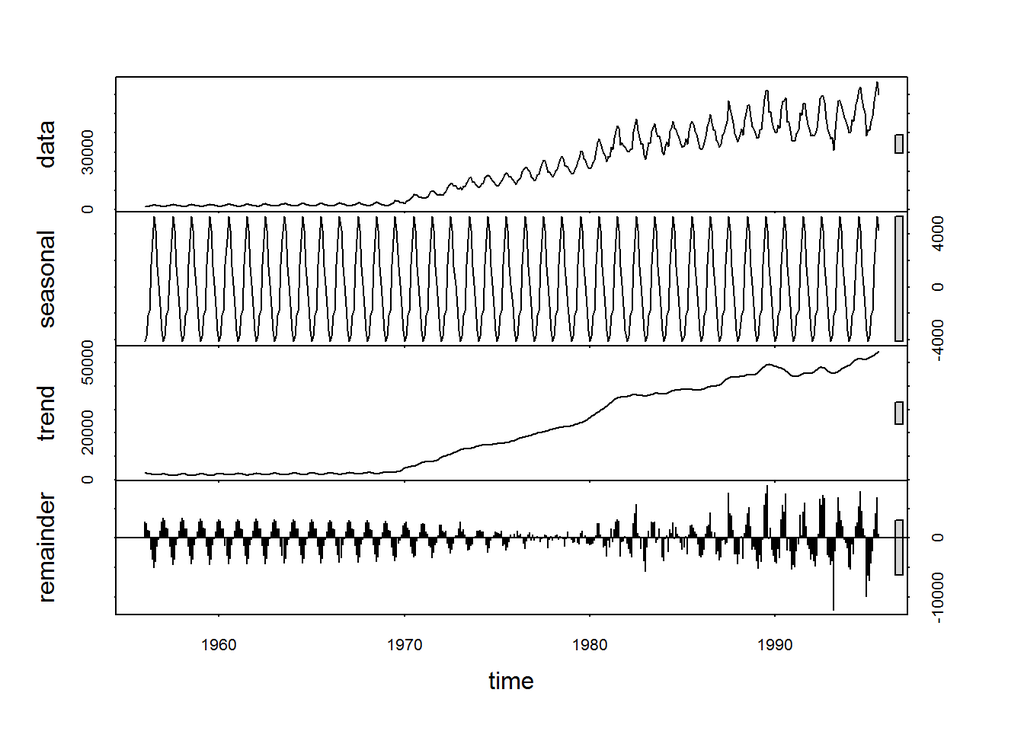

```r
#Get seasonally adjusted data constructed by removing the seasonal component
deseasonal_cnt <- seasadj(decomposed)
plot(decomposed)
```

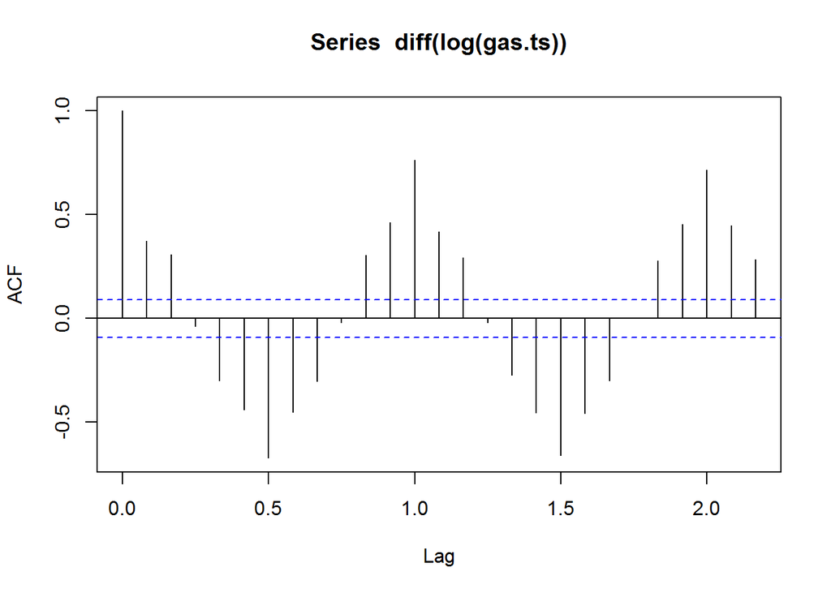

```r
#Plot ACF and PACF on diff log of gas dataset
acf(diff(log(gas.ts)))
```

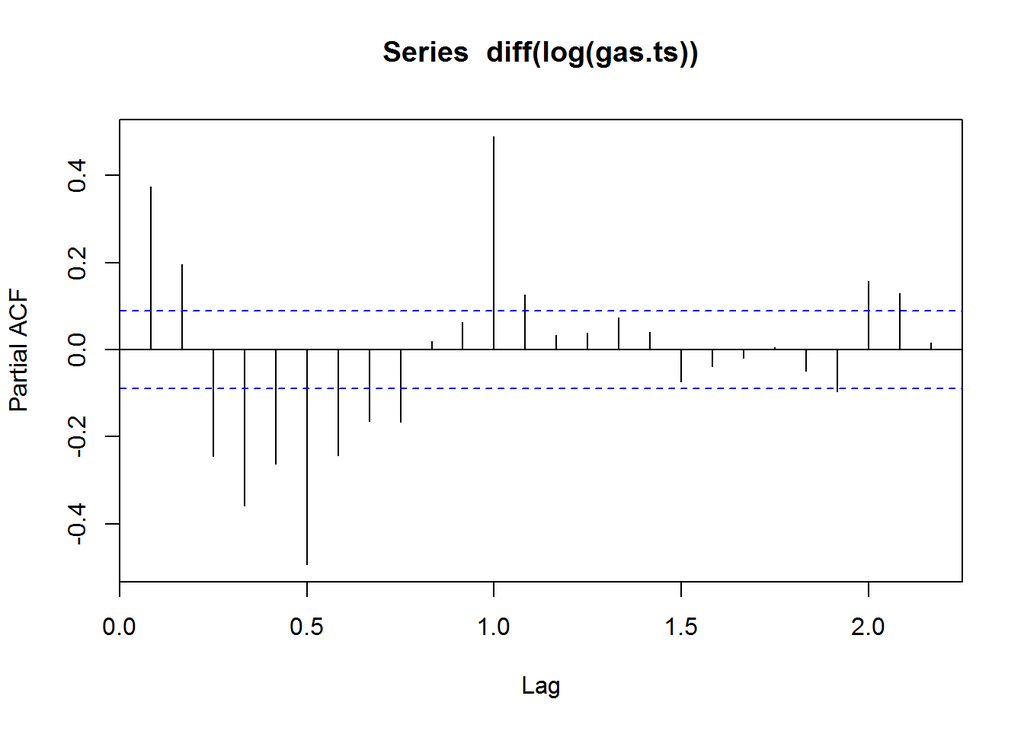

```r
pacf(diff(log(gas.ts)))
```

For q value, we will check the ACF plot. Number of lines first beyond blue are having significant correlation. So, we consider q value as “1” from above ACF plot.

For p value, we will check the PACF plot, Number of lines before first line below blue line can be considered for p value. So, we consider p as “9” from above PACF plot.

For d value, we will consider the differencing lag as “1”.

Build ARIMA model with above values of p, d, q using seasonally adjusted data. Check the forecast values and write them to csv for reference.

```r
#Build ARIMA modeland forecast for next 12 months
fit = arima(deseasonal_cnt, order=c(9,1,1))
fcast <- forecast(fit, h=12)
fcast
```

```
##          Point Forecast    Lo 80    Hi 80    Lo 95    Hi 95
## Sep 1995       55414.45 53275.99 57552.92 52143.95 58684.95
## Oct 1995       51048.87 48443.90 53653.84 47064.92 55032.82
## Nov 1995       48705.14 45745.30 51664.98 44178.45 53231.83
## Dec 1995       46139.81 43020.38 49259.24 41369.05 50910.56
## Jan 1996       44932.97 41724.23 48141.70 40025.63 49840.31
## Feb 1996       46243.29 42979.93 49506.65 41252.41 51234.16
## Mar 1996       48437.70 45174.30 51701.10 43446.76 53428.64
## Apr 1996       51493.42 48225.22 54761.63 46495.14 56491.71
## May 1996       55027.23 51754.94 58299.52 50022.70 60031.77
## Jun 1996       56597.84 53323.07 59872.62 51589.51 61606.18
## Jul 1996       57605.81 54301.19 60910.42 52551.83 62659.78
## Aug 1996       56556.78 53167.70 59945.87 51373.62 61739.94
```

```r
#Write the forecasted values to csv
write.csv(fcast, file = "D:/SivaBulusu/GasProductionForecast/arima911.csv")
```

Plot the forecast and check accuracy.

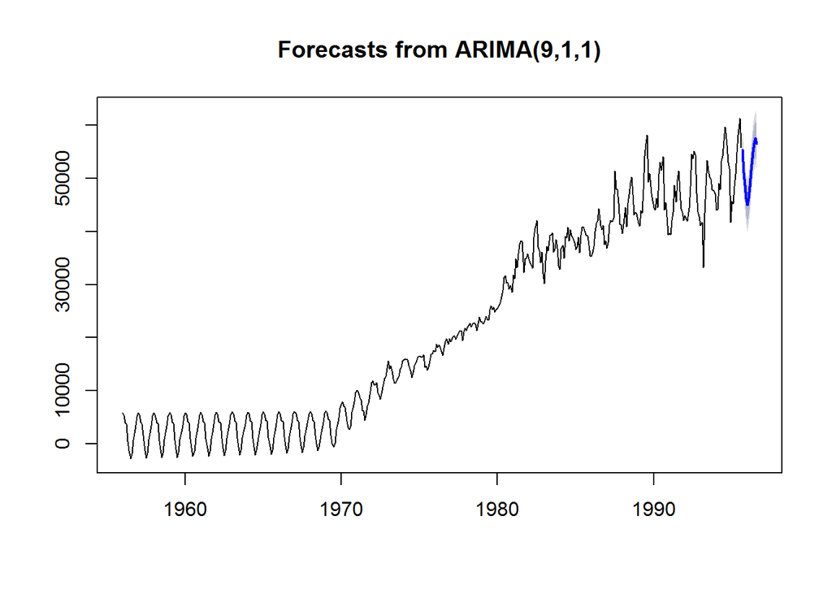

```r
#Plot the forecast
plot(fcast)
```

```r
#Check accuracy
accuracy(fcast)
```

```
##                    ME   RMSE      MAE        MPE     MAPE      MASE        ACF1
## Training set 369.1781 1666.9 1146.519 -0.5700892 23.92406 0.6145878 -0.06282288
```

Plot looks as expected.

Measures of accuracy are mentioned below:

ME: Mean Error = 369.17 RMSE: Root Mean Squared Error = 1666.9 MAE: Mean Absolute Error = 1146.519 MPE: Mean Percentage Error = -0.57 MAPE: Mean Absolute Percentage Error = 23.92 MASE: Mean Absolute Scaled Error = 0.614 ACF1: Autocorrelation of errors at lag 1. = -0.062

Build ARIMA model with “auto.arima” with seasonal as false to get the best non seasonal model. Check the forecast values and write them to csv for reference.

```r
#Use auto.arima to get the best model
#Use auto.arima with seasonal as false to get the best non seasonal model
fit_nonseasonal<-auto.arima(deseasonal_cnt, seasonal=FALSE)
fcast_nonseasonal <- forecast(fit_nonseasonal, h=12)
fcast_nonseasonal
```

```
##          Point Forecast    Lo 80    Hi 80    Lo 95    Hi 95
## Sep 1995       55146.32 52593.84 57698.79 51242.64 59050.00
## Oct 1995       53112.53 49649.00 56576.07 47815.52 58409.55
## Nov 1995       52529.35 48255.97 56802.72 45993.78 59064.91
## Dec 1995       52230.69 47494.53 56966.85 44987.36 59474.02
## Jan 1996       52724.58 47714.92 57734.23 45062.97 60386.19
## Feb 1996       53015.59 47881.95 58149.23 45164.37 60866.81
## Mar 1996       53210.30 48002.00 58418.60 45244.90 61175.71
## Apr 1996       53359.30 48095.33 58623.27 45308.76 61409.85
## May 1996       53486.60 48175.12 58798.08 45363.39 61609.81
## Jun 1996       53603.60 48248.40 58958.80 45413.52 61793.67
## Jul 1996       53715.71 48318.69 59112.73 45461.67 61969.74
## Aug 1996       53825.50 48387.69 59263.30 45509.09 62141.90
```

```r
#Write the forecasted values to csv
write.csv(fcast, file = "D:/SivaBulusu/GasProductionForecast/fcast_nonseasonal.csv")
```

Plot the forecast and check accuracy.

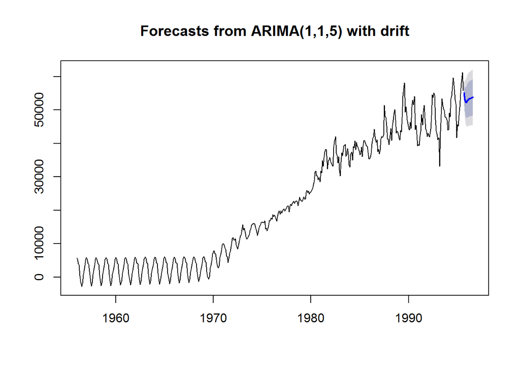

```r
#Plot the forecast
plot(fcast_nonseasonal)
```

```r
#Check accuracy
accuracy(fcast_nonseasonal)
```

```
##                     ME     RMSE      MAE      MPE     MAPE      MASE       ACF1
## Training set -18.03949 1974.902 1363.712 -23.2232 58.24472 0.7310134 0.01704564
```

Plot looks as parabolic at the end.

Measures of accuracy are mentioned below:

ME: Mean Error = -18.03 RMSE: Root Mean Squared Error = 1974.9 MAE: Mean Absolute Error = 1363.71 MPE: Mean Percentage Error = -23.22 MAPE: Mean Absolute Percentage Error = 58.24 MASE: Mean Absolute Scaled Error = 0.731 ACF1: Autocorrelation of errors at lag 1. = 0.017

Build ARIMA model with “auto.arima” with seasonal as true to get the best model without restricting the search to seasonal model. Check the forecast values and write them to csv for reference.

```r
#Use auto.arima with seasonal as true to get the best seasonal model
fit_seasonal = auto.arima(deseasonal_cnt, seasonal=TRUE)
fcast_seasonal <- forecast(fit_seasonal, h=12)
fcast_seasonal
```

```
##          Point Forecast    Lo 80    Hi 80    Lo 95    Hi 95
## Sep 1995       55379.54 53318.24 57440.84 52227.06 58532.03
## Oct 1995       52312.31 49995.02 54629.61 48768.32 55856.31
## Nov 1995       51191.51 48674.55 53708.48 47342.15 55040.88
## Dec 1995       46794.26 44150.85 49437.67 42751.52 50837.01
## Jan 1996       47402.21 44659.57 50144.85 43207.71 51596.71
## Feb 1996       47317.68 44492.77 50142.59 42997.35 51638.01
## Mar 1996       48833.30 45935.64 51730.96 44401.71 53264.89
## Apr 1996       51185.67 48221.27 54150.07 46652.01 55719.33
## May 1996       55822.40 52795.19 58849.61 51192.68 60452.12
## Jun 1996       58592.82 55505.54 61680.11 53871.23 63314.42
## Jul 1996       60483.23 57337.88 63628.57 55672.84 65293.62
## Aug 1996       59135.47 55933.64 62337.30 54238.70 64032.25
```

```r
#Write the forecasted values to csv
write.csv(fcast, file = "D:/SivaBulusu/GasProductionForecast/fcast_seasonal.csv")
```

Plot the forecast and check accuracy.

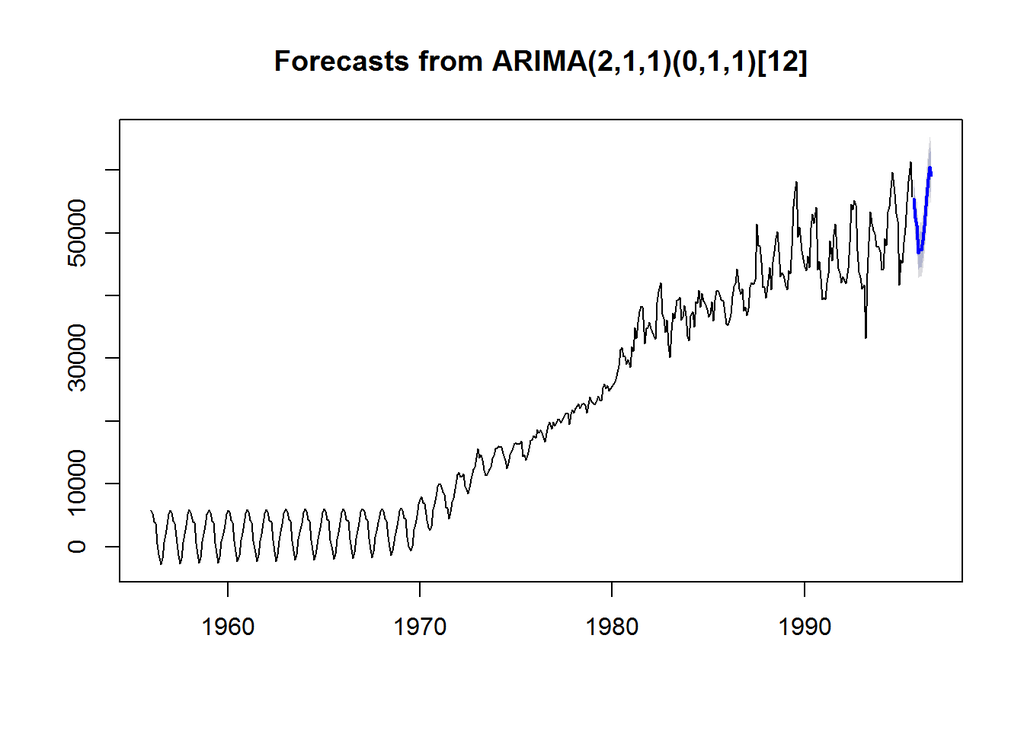

```r
#Plot the forecast
plot(fcast_seasonal)
```

```r
#Check accuracy
accuracy(fcast_seasonal)
```

```
##                    ME     RMSE      MAE      MPE     MAPE      MASE        ACF1
## Training set 27.69395 1579.457 893.5005 3.275292 7.956317 0.4789581 0.002272617
```

Plot looks as expected at the end like in previous entire series.

Measures of accuracy are mentioned below:

ME: Mean Error = 27.69 RMSE: Root Mean Squared Error = 1579.45 MAE: Mean Absolute Error = 893.5 MPE: Mean Percentage Error = 3.27 MAPE: Mean Absolute Percentage Error = 7.95 MASE: Mean Absolute Scaled Error = 0.478 ACF1: Autocorrelation of errors at lag 1. = 0.002

## Compare measures of accuracy and conclude

Among the 3 models created, 3rd model(fit_seasonal) can be preferred as it has lesser value of error components.